# 多元统计分析--理论与代码总结

#### 3.3.1 进一步检验显著性

**多重t检验:**

```
{r}
p.adjust(p, method=p.adjust.methods, n=length(p))
pairwise.t.test(x, g, p.adjust.method=p.adjust.methods, pool.sd=TRUE, ...)
# p.adjust.method: "holm" "hochberg" "hommel" "bonferroni" "BH" "BY" "fdr" "none"
```

其中p.adjust中的p为p值组成的向量,pairwise.t.test中x与g分别为数值向量和因子向量。  
当比较次数较多时, Bonferroni方法的效果较好, 所以在作多重t检验时常采用Bonferroni法对p进行调整. 实际上, 它采用$a = a1/k $作为给出“有无显著差异”的检验水平, 其中k为两两比较的次数, a1为累积I类错误的概率.

```r
t.test(c(25.6, 22.2, 28.0, 29.8), c(24.4, 30.0, 29.0, 27.5))
```

```
	Welch Two Sample t-test

data:  c(25.6, 22.2, 28, 29.8) and c(24.4, 30, 29, 27.5)
t = -0.64713, df = 5.5402, p-value = 0.5434
alternative hypothesis: true difference in means is not equal to 0
95 percent confidence interval:
 -6.437607  3.787607
sample estimates:
mean of x mean of y
   26.400    27.725
```

```r
p.adjust(0.5434, method="bonferroni", 5)
```

1

```r
pairwise.t.test(X, A, p.adjust.method="bonferroni")
```

```
	Pairwise comparisons using t tests with pooled SD

data:  X and A

  1     2     3     4
2 1.000 -     -     -
3 1.000 1.000 -     -
4 1.000 1.000 1.000 -
5 0.189 0.048 0.104 0.020

P value adjustment method: bonferroni
```

**同时置信区间:**
若经前面的F检验, H0被拒绝了, 则因子A的r个水平的效应不全相等, 这时我们希望对效应之差$α_i-α_j$作出置信区间。 $$ \frac{\mathop{\min}_{i} X_i -\mathop{\max}_{i} X_i}{\hat σ^2/σ^2} ~ q(n, m) $$

```
{r}
TukeyHSD(x, which, ordered=FALSE, conf.level=0.95...)
```

x为方差分析的对象, which是给出需要计算比较区间的因子向量,ordered是逻辑值, 如果为"true", 则因子的水平先递增排序, 从而使得因子间差异均以正值出现. conf.level是置信区间。

```r
sales <- data.frame(X=c(23, 19, 21, 13, 24, 25, 28, 27, 20, 18, 19, 15, 22, 25, 26, 23, 24, 23, 26, 27),
                  A=factor(rep(1:5, c(4, 4, 4, 4, 4))))
summary(aov(X~A, sales))
TukeyHSD(aov(X~A, sales))
```

```
            Df Sum Sq Mean Sq F value  Pr(>F)
A            4  212.8   53.20    7.98 0.00118 **
Residuals   15  100.0    6.67
---
Signif. codes:  0 '***' 0.001 '**' 0.01 '*' 0.05 '.' 0.1 ' ' 1
```

```
  Tukey multiple comparisons of means
    95% family-wise confidence level

Fit: aov(formula = X ~ A, data = sales)

$A
    diff        lwr       upr     p adj
2-1    7   1.362247 12.637753 0.0120117
3-1   -1  -6.637753  4.637753 0.9805632
4-1    5  -0.637753 10.637753 0.0944731
5-1    6   0.362247 11.637753 0.0344328
3-2   -8 -13.637753 -2.362247 0.0041527
4-2   -2  -7.637753  3.637753 0.8062057
5-2   -1  -6.637753  4.637753 0.9805632
4-3    6   0.362247 11.637753 0.0344328
5-3    7   1.362247 12.637753 0.0120117
5-4    1  -4.637753  6.637753 0.9805632
```

#### 3.3.2 前提假设检验

**正态性检验:**

```r
shapiro.test(miscellany$X)
```

```
	Shapiro-Wilk normality test

data:  miscellany$X
W = 0.94719, p-value = 0.3264
```

**方差齐次(Bartlett):**  
H0:各因子水平下的方差相同; H1:各因子水平下的方差不齐

```r
bartlett.test(X~A, data=miscellany)
```

```
	Bartlett test of homogeneity of variances

data:  X by A
Bartlett's K-squared = 7.0966, df = 4, p-value = 0.1309
```

**方差齐次(Levene):**  
Levene检验对原始数据是否为正态不灵敏，所以比较稳健，因此推荐采用LEVENE方差齐性检验。R的程序包car中提供了Levene检验的函数leveneTest( )

```r
library("car")
library("carData")
leveneTest(miscellany$X, miscellany$A)
```

A anova: 2 × 3

|  | Df <int> | F value <dbl> | Pr(>F) <dbl> |
| --- | --- | --- | --- |
| group | 4 | 1.73735 | 0.194193 |
|  | 15 | NA | NA |

## 4. 回归

### 4.1 回归模型建立

回归模型是建立在这样一种**评价标准**下:我们构建的模型到每个训练数据的残差平方总和最小.
由于这是$RSS$关于$β_0$和$β_1$的函数,可以通过求导找到最低点,这个最低点对应的$β_0$和$β_1$就是使用最小二乘法得到的模型参数.
$$ \hat β_1 = \frac{\sum_{i-1}^n (X_i-\hat X)(Y_i-\hat Y)}{\sum_{i-1}^n (X_i-\hat X)^2} = \frac{S_{xy}}{S_{xx}}, \quad \hat β_0 = \hat Y - \hat β_1 \hat X, \quad \hat σ^2 = \frac{\sum_{i-1}^n (Y_i - \hat β_0 - \hat β_1 X_i)}{n-2} $$

#### 4.1.1 模型的基本假设

我们在使用线形回归之前有如下的**基本假设**:

- 可加性(线性性)
- 自变量之间相互独立
- 误差项符合正态分布
- 误差项之间相互独立
- 误差项方差为常数(同方差性)

我们可以看到误差项被假设为符合正态分布, X被假设为固定的, 所以Y也符合正态分布, 那作为Y的线性组合两个参数也应该符合正态分布, 其分布取决于均值与方差.按照这个思路, 我们有必要估计参数的置信区间和显著性.

#### 4.1.2 参数显著性检验与区间估计

**参数显著性检验:**
对于显著性我们原假设是系数为0, 即对应自变量分布与因变量分布之间找不出关系, 备择假设则是其系数不等于0.
我们有三种方法对其进行检验:t检验, F检验, 相关系数检验.
其中t检验使用单变量, 给定均值为0. $T = \frac{\hat β_1}{Sd(\hat β_1)} = \frac{\hat β_1 \sqrt {S_{xx}}}{\hat σ} \sim t(n-2)$
F检验$F = \frac{\hat {β_1} S_{xx}}{\hat{σ_2}} \sim F(1, n-2)$
相关系数检验$γ(X,Y) = \frac{S_{xy}}{\sqrt {S_{xx}S_{xy}}}$
**参数区间估计:**
$$T = \frac{\hat β_i - β_i}{Sd(\hat β_i)} \sim t(n-2)$$

#### 4.1.3 残差与模型评价

在上面提到的评价标准上, 我们使用两个指标评价模型的好坏:$RSE$与$R^2$, 分别评价模型估计的偏离量和方差解释程度.
$$RSE = \sqrt{\frac{RSS}{n-2}}, \quad R^2 = 1-\frac{RSS}{TSS}, \quad RSS = \sum_{i=1}^n(y_i-\hat {y_i})^2, \quad TSS = \sum_{i=1}^n(y_i-\bar y)^2$$
结合上面的评价标准, 不难发现所有的评价指标都是从"残差"这一概念衍化而来的, 同时我们还有两种其他类型的残差, 他们可以用于识别强影响点. 其中标准化残差是在残差基础上进行标准化使其服从$N(0,1)$分布的一种形式, 而学生化残差是考虑到残差标准化后服从T分布而不是正态分布, 所以在计算标准化残差时使用去除所在观测残差的估计标准差进行计算.

#### 4.1.4 变量选择

我们不太可能把所有潜在变量都作为模型的变量，而模型包含少量变量又会导致模型解释性较差，所以我们需要找到一个方法找到合适数量的变量。  
回归变量的选择我们主要考虑两个因素: $R^2$与变量数$p$，其中变量数的上升无论如何也会增加$R_2$，所以我们一般添加关于$p$的罚因子限制变量数，下面是一些常见的变量选择方法。

- Adjusted R2:
  $$adj\quad R^2 = 1-\frac{n-1}{n-p}(1-R^2)$$
- Cp: 选择$(p, C_p)$最接近$y=x$且$C_p$最小的点 $$C_p = \frac{(n-p)RMS_p}{RMS}-(n-2p), \quad RMS_p = \frac{RSS_p}{n-p}$$
- AIC, BIC: 两者越小越好 $$AIC=n\ln{\frac{RSS_p}{n}}+2p, \quad BIC=n\ln{\frac{RSS_p}{n}}+p\ln n$$

### 4.2 回归诊断

回归模型会因为**数据不规范**, **不符合应用条件**和**关系存在问题**而有较差的表现.

#### 4.2.1 数据不规范

其中**数据不规范**主要表现为存在离群点, 离群点的存在不一定是因为数据记录存在问题, 大多数情况可能是数据记录并没有出现错误, 这部分数据也是真实的, 但这部分数据脱离了其他数据的范畴, 可能并不是我们想要讨论的数据.  
一部分离群点不能被模型解释, 另一部分离群点的自变量如果偏离其他数据的分布会拉偏模型, 这部分离群点也被称为"高杠杆值", 如果一个点既是离群点也是高杠杆值, 则被称为"强影响点", 具有很高的危害性.  
一般我们认为小样本观测的标准残差绝对值>2的就属于离群点(大样本>4), 强影响点的识别则需要使用Cook距离, Cook距离度量观测对模型的影响程度, 一般认为$D_i > 4 / n$则为强影响点, n为观测数. 除此之外, 还有DFFITS($D>2\sqrt{\frac{p+1}{n}}$, $p+1$为向量β的维度)和COVRATIO(离1越远影响越大)两个统计量也可以用于计算观测对模型的影响, 一般思路都是计算扣除某个观测后的模型与原模型比较.

#### 4.2.2 关系存在问题

变量之间的关系存在问题主要有两种表现形式: **自变量之间存在关联(共线性)** 和**自变量与因变量关系为非线性**.  
**非线性:**  
非线性主要是因为x与y的关系并不是线形, 体现在残差图中残差大致能拟合为方差平均分布的一条曲线, 这个时候需要更改变量的形式, 例如二次、幂函数、对数形式进行拟合，这里不约束是对自变量还是因变量进行改变，但是对因变量进行改变需要注意残差分布的改变。  
常用得变换有：

- 开方变换$Z=\sqrt{Y}(Y>0)$
- 对数变换$Z=\ln{Y}(Y>0)$
- 倒数变换$Z=1/Y(Y\neq 0)$
- BOX-COX变换$Z=\frac{X^λ-1}{λ}$($λ=0$为对数变换) **共线性:**  
  共线性产生的原因是自变量之间存在相关关系, 使得RSS关于参数的接近二元正态分布的函数扭曲为具有类似峡谷形状的函数, 使得数据微小的变化就可能产生较大的变动, 这样会增大参数的标准误差从而降低t统计量可能使我们错过重要变量。  
  对于存在共线性的变量，他们之间的相关系数往往也比较大，两者的函数接近于直线，可以去掉其中一个变量，或者构建关于这两个值的指标(例如平均值)消除共线性。  
  我们一般通过"方差膨胀因子"判断变量的共线性，一般膨胀因子>10就被认为共线性较为严重。除此之外还有条件指数(>100强相关，30~100弱相关)、特征值等方法计算共线性程度。

#### 4.2.3 不符合应用条件

我们对于模型的基本假设是模型的**随机误差项独立、正态分布、方差相同**，如果数据不符合这三个假设则需要进行一些修正。  
**方差不同:**  
这种情况意味着随着y的变化残差的分布产生变化，这种情况需要转换y的形式使得转换后的变量其残差分布均匀。  
这里我们认为这种转换仍然属于正常的回归，回归模型的推广在于将符合泊松、二项等分布的因变量通过转换变为符合正态分布的因变量。  
**分布非正态:**  
非正态分布通过QQ plot查看，如果学生化残差与分位数函数呈现为一条直线则说明符合正态性，如果不符合正态性可以试着改变自变量或因变量的形式。  
**误差项自相关:**  
误差之间存在相关关系，一般通过DW指标$DW = \frac{\sum(e_t-e_t-1)^2}{\sum e_t^2}$

### 4.3 扩展应用

#### 4.3.1 处理定性变量

对于定性变量，我们如果有n个水平，则添加n-1个哑变量，哑变量取值为0、1，分别表示第一个水平外的其他水平，哑变量可以有任意系数，甚至可以再包含一个线性模型，这个时候就属于交叉项。

#### 4.3.2 广义线性模型

对于广义线形模型，我们可以把指数分布族任一种分布通过连接函数转换为服从正态分布的统计量。

```
{r}
glm(formula, family=family(link=function), data=)
```

| 分布族(family) | 默认连接函数 |
| --- | --- |
| binomial | link="logit" |
| gaussian | link="identity" |
| gamma | link="inverse" |
| inverse.gaussian | link="1/mu^2" |
| poisson | link="log" |
| quasi | link="identity", variance="constant" |
| quasibinomial | link="logit" |
| quasipoisson | link="log" |

```r
# 进行拟合
x <- c(274, 180, 375, 205, 86, 265, 98, 330, 195, 53, 430, 372, 236, 157, 370)
y <- c(162, 120, 223, 131, 67, 169, 81, 192, 116, 55, 252, 234, 144, 103, 212)
A <- data.frame(x, y)
lm.reg <- lm(y~x)
summary(lm.reg)
```

```
Call:
lm(formula = y ~ x)

Residuals:
    Min      1Q  Median      3Q     Max
-9.9610 -4.6079 -0.2618  3.1500 14.2152

Coefficients:
            Estimate Std. Error t value Pr(>|t|)
(Intercept) 22.59595    3.92745   5.753 6.67e-05 ***
x            0.53008    0.01472  36.007 2.08e-14 ***
---
Signif. codes:  0 '***' 0.001 '**' 0.01 '*' 0.05 '.' 0.1 ' ' 1

Residual standard error: 6.435 on 13 degrees of freedom
Multiple R-squared:  0.9901,	Adjusted R-squared:  0.9893
F-statistic:  1297 on 1 and 13 DF,  p-value: 2.079e-14
```

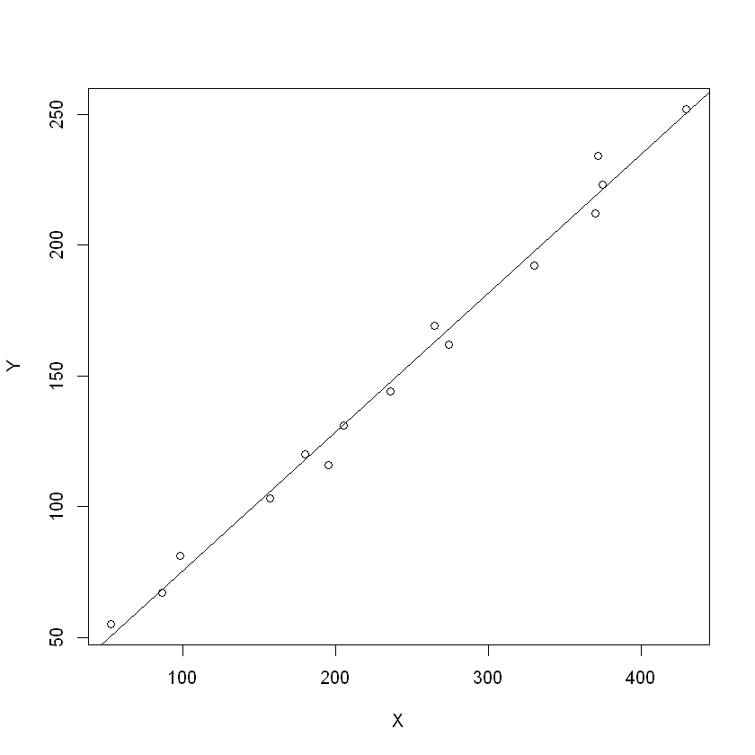

```r
# 绘制拟合曲线，仅适合一元回归
plot(x, y, xlab="X", ylab="Y")
abline(lm.reg)
```

```r
# 列出模型参数
coef(lm.reg)
# 列出置信区间
confint(lm.reg)
# 列出模型残差值
    # 残差
    residuals(lm.reg)
    # 标准化残差
    rstandard(lm.reg)
    # 学生化残差
    rstudent(lm.reg)
# 列出模型方差分析表
anova(lm.reg)
```

**(Intercept)**

22.5959459016291

**x**

0.530077443870812

A matrix: 2 × 2 of type dbl

|  | 2.5 % | 97.5 % |
| --- | --- | --- |
| (Intercept) | 14.1112160 | 31.0806758 |
| x | 0.4982738 | 0.5618811 |

**1**

-5.83716552223161

**2**

1.99011420162481

**3**

1.62501264681646

**4**

-0.261821895145504

**5**

-1.18260607451887

**6**

5.93353147260578

**7**

6.45646459903138

**8**

-5.521502378997

**9**

-9.96104745643738

**10**

4.30994957321792

**11**

1.47075323392181

**12**

14.2152449784289

**13**

-3.69422265514068

**14**

-2.81810458934654

**15**

-6.72460013382948

**1**

-0.941647888406408

**2**

0.323581377021246

**3**

0.275454133541534

**4**

-0.0422737005712115

**5**

-0.20464193908611

**6**

0.955847352675536

**7**

1.10444347480719

**8**

-0.90817954168098

**9**

-1.61211389152673

**10**

0.774937747058175

**11**

0.264281607840462

**12**

2.40370120444346

**13**

-0.594262442121898

**14**

-0.462694900889453

**15**

-1.13526686988273

**1**

-0.937233787593847

**2**

0.312146521380489

**3**

0.265423481666311

**4**

-0.0406180496703457

**5**

-0.19693106905634

**6**

0.9524265130888

**7**

1.11469922657617

**8**

-0.901621186942299

**9**

-1.73159746439468

**10**

0.762352540105281

**11**

0.254598414008712

**12**

3.09838749863241

**13**

-0.578865525332224

**14**

-0.448249131362441

**15**

-1.14918106257252

A anova: 2 × 5

|  | Df <int> | Sum Sq <dbl> | Mean Sq <dbl> | F value <dbl> | Pr(>F) <dbl> |
| --- | --- | --- | --- | --- | --- |
| x | 1 | 53692.5691 | 53692.56911 | 1296.526 | 2.079173e-14 |
| Residuals | 13 | 538.3642 | 41.41263 | NA | NA |

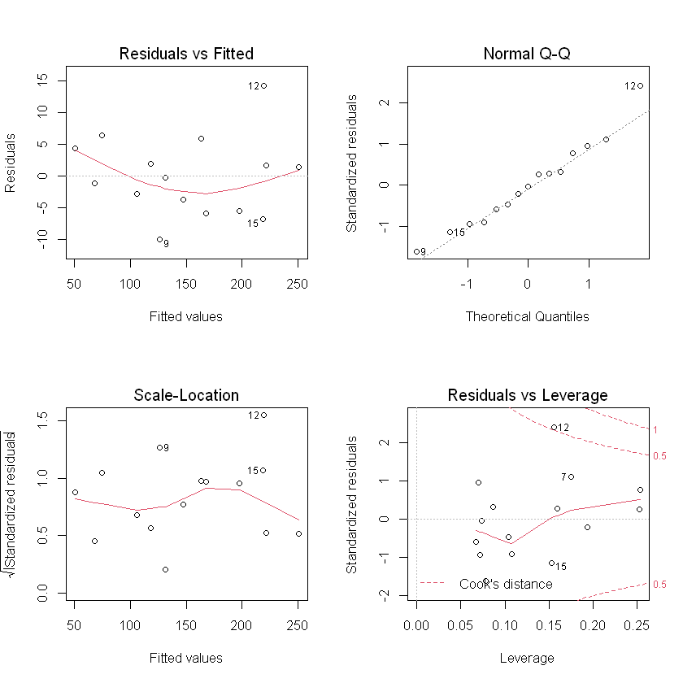

```r
# 绘制回归诊断图
op <- par(mfrow=c(2,2))
plot(lm.reg)
par(op)
```

```r
# 在训练集上测试
fitted(lm.reg)
# 使用模型进行预测
predict(lm.reg, data.frame(x=42), interval='prediction', level=0.95)
```

**1**

167.837165522232

**2**

118.009885798375

**3**

221.374987353184

**4**

131.261821895146

**5**

68.1826060745189

**6**

163.066468527394

**7**

74.5435354009686

**8**

197.521502378997

**9**

125.961047456437

**10**

50.6900504267821

**11**

250.529246766078

**12**

219.784755021571

**13**

147.694222655141

**14**

105.818104589347

**15**

218.724600133829

A matrix: 1 × 3 of type dbl

|  | fit | lwr | upr |
| --- | --- | --- | --- |
| 1 | 44.8592 | 29.15834 | 60.56006 |

```r
# 逐步回归
y <- c(11.2, 8.8, 12.3, 11.6, 13.4, 18.3, 11.1, 12.1, 9.6, 8.4, 9.3, 10.6, 8.4, 9.6, 10.9, 10.1, 14.8, 9.1, 10.8, 10.2, 13.6, 14.9, 16.0, 13.2, 20.0, 13.3, 10.4)
x1 <- c(5.68, 3.79, 6.02, 4.85, 4.60, 6.05, 4.90, 7.08, 3.85,4.65, 4.59, 4.29, 7.97, 6.19, 6.13, 5.71, 6.40,6.06, 5.09, 6.13, 5.78, 5.43, 6.50, 7.98, 11.54,5.84, 3.84)
x2 <- c(1.90, 1.64, 3.56, 1.07, 2.32, 0.64, 8.50, 3.00, 2.11, 0.63, 1.97, 1.97, 1.93, 1.18, 2.06, 1.78, 2.40, 3.67, 1.03, 1.71, 3.36, 1.13, 6.21, 7.92, 10.89, 0.92, 1.20)
x3 <- c(4.53, 7.32, 6.95, 5.88, 4.05, 1.42, 12.60, 6.75, 16.28, 6.59, 3.61, 6.61, 7.57, 1.42, 10.35, 8.53, 4.53,12.79, 2.53, 5.28, 2.96, 4.31, 3.47, 3.37, 1.20, 8.61, 6.45)
x4 <- c(8.2, 6.9, 10.8, 8.3, 7.5, 13.6, 8.5, 11.5, 7.9, 7.1, 8.7, 7.8, 9.9, 6.9, 10.5, 8.0, 10.3, 7.1, 8.9, 9.9, 8.0, 11.3, 12.3, 9.8, 10.5, 6.4, 9.6)
blood <- data.frame(y, x1, x2, x3, x4)
lm.reg <- lm(y~x1+x2+x3+x4, data=blood)

lm.step <- step(lm.reg)
summary(lm.step)
```

```
Start:  AIC=42.16
y ~ x1 + x2 + x3 + x4

       Df Sum of Sq     RSS    AIC
- x1    1    0.6129  89.454 40.343
<none>               88.841 42.157
- x2    1   11.9627 100.804 43.568
- x3    1   20.0635 108.905 45.655
- x4    1   27.7939 116.635 47.507

Step:  AIC=40.34
y ~ x2 + x3 + x4

       Df Sum of Sq     RSS    AIC
<none>               89.454 40.343
- x3    1    25.690 115.144 45.159
- x2    1    26.530 115.984 45.356
- x4    1    32.269 121.723 46.660
```

```
Call:
lm(formula = y ~ x2 + x3 + x4, data = blood)

Residuals:
    Min      1Q  Median      3Q     Max
-3.2692 -1.2305 -0.2023  1.4886  4.6570

Coefficients:
            Estimate Std. Error t value Pr(>|t|)
(Intercept)   6.4996     2.3962   2.713  0.01242 *
x2            0.4023     0.1541   2.612  0.01559 *
x3           -0.2870     0.1117  -2.570  0.01712 *
x4            0.6632     0.2303   2.880  0.00845 **
---
Signif. codes:  0 '***' 0.001 '**' 0.01 '*' 0.05 '.' 0.1 ' ' 1

Residual standard error: 1.972 on 23 degrees of freedom
Multiple R-squared:  0.5981,	Adjusted R-squared:  0.5456
F-statistic: 11.41 on 3 and 23 DF,  p-value: 8.793e-05
```

**26:** 2.53353140087267

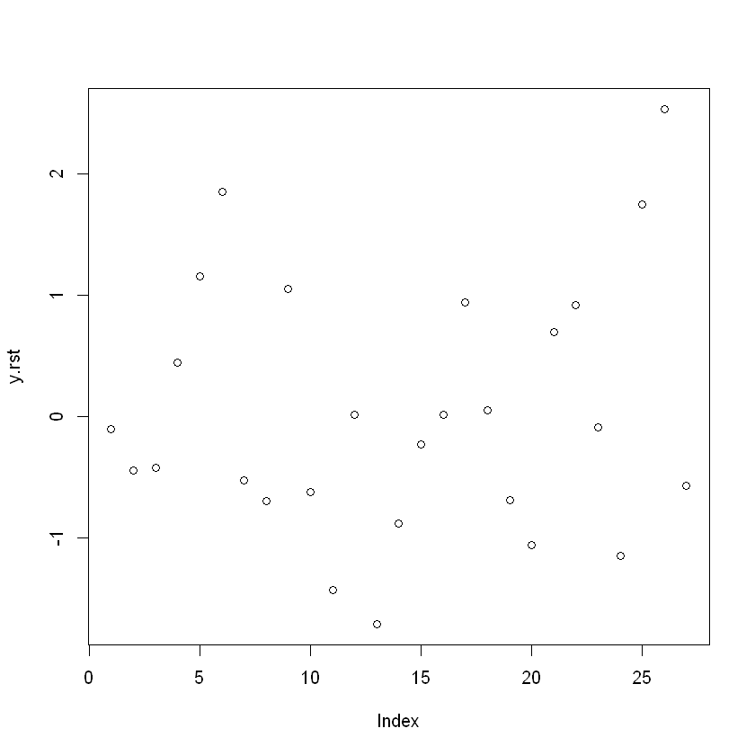

```r
# 绘制标准残差图
y.rst <- rstandard(lm.step)
y.rst[y.rst > 2]
plot(y.rst)
```

```r
# 删除离群点重新计算
lm.fit <- lm(y~., data=blood[-26,])
lm.step <- step(lm.fit)
y.rst <- rstandard(lm.step)
summary(lm.step)
```

```
Start:  AIC=33.43
y ~ x1 + x2 + x3 + x4

       Df Sum of Sq     RSS    AIC
- x1    1     0.470  64.489 31.619
<none>               64.019 33.428
- x2    1    21.383  85.403 38.921
- x3    1    26.592  90.611 40.460
- x4    1    43.401 107.420 44.885

Step:  AIC=31.62
y ~ x2 + x3 + x4

       Df Sum of Sq     RSS    AIC
<none>               64.489 31.619
- x3    1    27.879  92.368 38.960
- x2    1    31.211  95.701 39.881
- x4    1    45.458 109.948 43.490
```

```
Call:
lm(formula = y ~ x2 + x3 + x4, data = blood[-26, ])

Residuals:
    Min      1Q  Median      3Q     Max
-3.1373 -0.9858 -0.2985  1.5085  2.5885

Coefficients:
            Estimate Std. Error t value Pr(>|t|)
(Intercept)  4.91254    2.15014   2.285 0.032333 *
x2           0.43825    0.13431   3.263 0.003561 **
x3          -0.29930    0.09705  -3.084 0.005425 **
x4           0.81259    0.20635   3.938 0.000702 ***
---
Signif. codes:  0 '***' 0.001 '**' 0.01 '*' 0.05 '.' 0.1 ' ' 1

Residual standard error: 1.712 on 22 degrees of freedom
Multiple R-squared:  0.7077,	Adjusted R-squared:  0.6678
F-statistic: 17.75 on 3 and 22 DF,  p-value: 4.412e-06
```

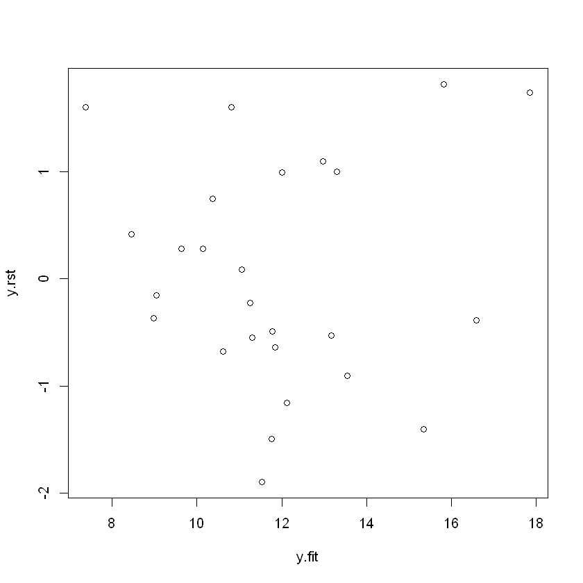

```r
# 检查是否服从方差同性
y.rst <- rstandard(lm.step)
y.fit <- predict(lm.step)
plot(y.rst~y.fit)
```

```r
# 变换形式
# x_new <- log(x4)
# x_new <- exp(x_new)
# x_new <- 1 / x4
# x_new <- sqrt(x4)
# library(MASS)
head(Boston)
lm.fit2 <- lm(medv~lstat+I(lstat^2), data=Boston)
for (i in 1:5){
    # 生成多项式
    lm.fit <- lm(medv~lstat+poly(lstat, i), data=Boston)
}
lm.fit3 <- update(lm.fit2, sqrt(.)~.)
```

A data.frame: 6 × 14

|  | crim <dbl> | zn <dbl> | indus <dbl> | chas <int> | nox <dbl> | rm <dbl> | age <dbl> | dis <dbl> | rad <int> | tax <dbl> | ptratio <dbl> | black <dbl> | lstat <dbl> | medv <dbl> |
| --- | --- | --- | --- | --- | --- | --- | --- | --- | --- | --- | --- | --- | --- | --- |
| 1 | 0.00632 | 18 | 2.31 | 0 | 0.538 | 6.575 | 65.2 | 4.0900 | 1 | 296 | 15.3 | 396.90 | 4.98 | 24.0 |
| 2 | 0.02731 | 0 | 7.07 | 0 | 0.469 | 6.421 | 78.9 | 4.9671 | 2 | 242 | 17.8 | 396.90 | 9.14 | 21.6 |
| 3 | 0.02729 | 0 | 7.07 | 0 | 0.469 | 7.185 | 61.1 | 4.9671 | 2 | 242 | 17.8 | 392.83 | 4.03 | 34.7 |
| 4 | 0.03237 | 0 | 2.18 | 0 | 0.458 | 6.998 | 45.8 | 6.0622 | 3 | 222 | 18.7 | 394.63 | 2.94 | 33.4 |
| 5 | 0.06905 | 0 | 2.18 | 0 | 0.458 | 7.147 | 54.2 | 6.0622 | 3 | 222 | 18.7 | 396.90 | 5.33 | 36.2 |
| 6 | 0.02985 | 0 | 2.18 | 0 | 0.458 | 6.430 | 58.7 | 6.0622 | 3 | 222 | 18.7 | 394.12 | 5.21 | 28.7 |

```r
# 计算强影响点
x1 <- c(1500, 1500, 3300, 4200, 2000, 2500, 2300, 2500)
x2 <- c(5000, 4000, 3000, 2500, 2000, 2500, 3500, 3000)
y <- c(96000, 95000, 95000, 94000, 90000, 92000, 95000, 94000)
money <- data.frame(x1, x2, y)
lm.reg <- lm(y~x1+x2, data=money)
# 这里的强影响点判断条件为4/n，n=8
influence.measures(lm.reg)
```

```
Influence measures of
	 lm(formula = y ~ x1 + x2, data = money) :

    dfb.1_   dfb.x1  dfb.x2  dffit  cov.r cook.d   hat inf
1  1.98495  0.06107 -3.8115 -5.167 0.0461 2.2838 0.633   *
2  0.11517 -0.26496  0.1105  0.533 1.7687 0.1018 0.301
3 -0.19968  0.33167  0.1285  0.468 1.7188 0.0791 0.262
4  0.88978 -1.56524 -0.3538 -1.871 1.8860 1.0056 0.660   *
5 -1.53634  1.11782  1.4109 -1.633 2.1558 0.8133 0.645   *
6 -0.16907  0.08580  0.1621 -0.242 2.1804 0.0233 0.226
7 -0.00772 -0.00518  0.1016  0.383 1.2356 0.0499 0.140
8  0.10067 -0.03095 -0.0686  0.305 1.4686 0.0335 0.132
```

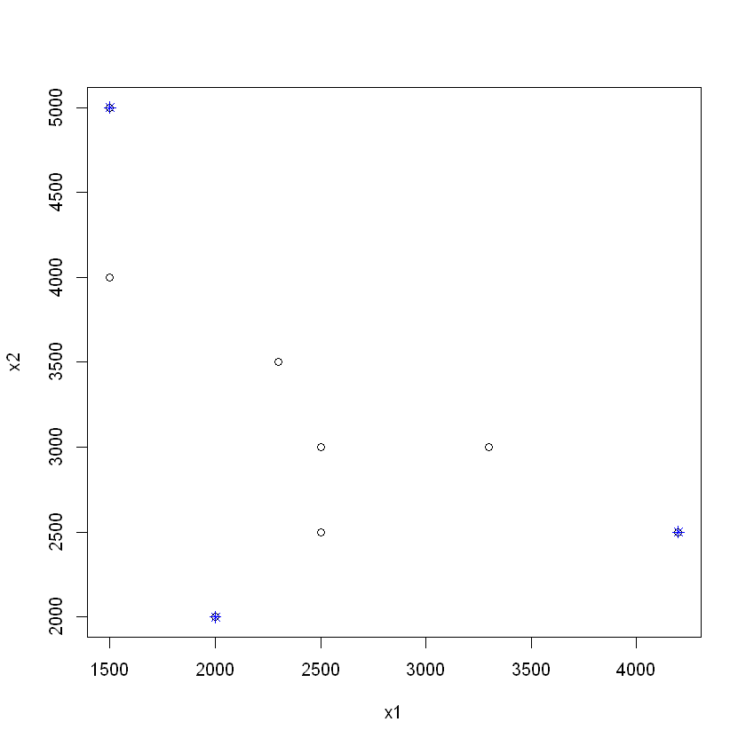

```r
# 显示强影响点
plot(x1, x2, xlab="x1", ylab="x2")
points(x1[c(1, 4, 5)], x2[c(1, 4, 5)], pch=8, col="blue")
```

```r
# 计算方差膨胀因子
x1 <- c(7, 1, 11, 11, 7, 11, 3, 1, 2, 21, 1, 11, 10)
x2 <- c(26, 29, 56, 31, 52, 55, 71, 31, 54, 47, 40, 66, 68)
x3 <- c(6, 15, 8, 8, 6, 9, 17, 22, 18, 4, 23, 9, 8)
x4 <- c(60, 52, 20, 57, 33, 22, 6, 44, 22, 18, 34, 12, 12)
y <- c(78.5, 74.3, 104.3, 87.6, 95.9, 109.2, 102.7, 72.5, 93.1, 115.9, 83.8, 113.3, 109.4)
cement <- data.frame(x1, x2, x3, x4)
lm.reg <- lm(y~x1+x2+x3+x4, data=cement)
summary(lm.reg)

library(DAAG)
vif(lm.reg, digits=3)
detach('package:DAAG', unload=TRUE)

library(car)
car::vif(lm.reg)

print("相关性系数:")
print(cor(cement))
```

```
Call:
lm(formula = y ~ x1 + x2 + x3 + x4, data = cement)

Residuals:
    Min      1Q  Median      3Q     Max
-3.2777 -1.3956 -0.2374  1.1650  4.0379

Coefficients:
            Estimate Std. Error t value Pr(>|t|)
(Intercept)  64.8044    22.8867   2.832  0.02210 *
x1            1.4805     0.3598   4.115  0.00337 **
x2            0.4918     0.2285   2.153  0.06351 .
x3            0.0510     0.3299   0.155  0.88097
x4           -0.1563     0.2120  -0.737  0.48205
---
Signif. codes:  0 '***' 0.001 '**' 0.01 '*' 0.05 '.' 0.1 ' ' 1

Residual standard error: 2.373 on 8 degrees of freedom
Multiple R-squared:  0.9834,	Adjusted R-squared:  0.9751
F-statistic: 118.6 on 4 and 8 DF,  p-value: 3.736e-07
```

**x1**

9.54

**x2**

26.9

**x3**

9.51

**x4**

31.4

**x1**

9.54381780583081

**x2**

26.9355796198015

**x3**

9.51346073963448

**x4**

31.3570733050444

```
[1] "相关性系数:"
           x1         x2          x3          x4
x1  1.0000000  0.2285795 -0.82413376 -0.28411263
x2  0.2285795  1.0000000 -0.13924238 -0.94796995
x3 -0.8241338 -0.1392424  1.00000000  0.04490711
x4 -0.2841126 -0.9479700  0.04490711  1.00000000
```

```r
# 处理共线性
cement$x_5 <- (cement$x2 + cement$x4) / 2
lm.reg <- lm(y~x1+x2+x_5, data=cement)
summary(lm.reg)
lm.reg <- lm(y~x1+x2+x3, data=cement)
summary(lm.reg)
```

```
Call:
lm(formula = y ~ x1 + x2 + x_5, data = cement)

Residuals:
    Min      1Q  Median      3Q     Max
-3.2023 -1.3709 -0.1269  1.2211  4.0546

Coefficients:
            Estimate Std. Error t value Pr(>|t|)
(Intercept) 67.95025    9.88986   6.871 7.30e-05 ***
x1           1.42823    0.11572  12.342 6.06e-07 ***
x2           0.64696    0.04376  14.783 1.28e-07 ***
x_5         -0.36619    0.23006  -1.592    0.146
---
Signif. codes:  0 '***' 0.001 '**' 0.01 '*' 0.05 '.' 0.1 ' ' 1

Residual standard error: 2.241 on 9 degrees of freedom
Multiple R-squared:  0.9834,	Adjusted R-squared:  0.9778
F-statistic: 177.3 on 3 and 9 DF,  p-value: 2.539e-08
```

```
Call:
lm(formula = y ~ x1 + x2 + x3, data = cement)

Residuals:
    Min      1Q  Median      3Q     Max
-3.2543 -1.4726  0.1755  1.5409  3.9711

Coefficients:
            Estimate Std. Error t value Pr(>|t|)
(Intercept) 48.19363    3.91330  12.315 6.17e-07 ***
x1           1.69589    0.20458   8.290 1.66e-05 ***
x2           0.65691    0.04423  14.851 1.23e-07 ***
x3           0.25002    0.18471   1.354    0.209
---
Signif. codes:  0 '***' 0.001 '**' 0.01 '*' 0.05 '.' 0.1 ' ' 1

Residual standard error: 2.312 on 9 degrees of freedom
Multiple R-squared:  0.9823,	Adjusted R-squared:  0.9764
F-statistic: 166.3 on 3 and 9 DF,  p-value: 3.367e-08
```

```r
# 广义线性模型预测方法
x1<-rep(c(1, 0, 1, 0, 1), c(5, 10, 10, 10, 10))
x2<-c(17, 44, 48, 55, 75, 35, 42, 57, 28, 20, 38, 45, 47, 52, 55, 68, 18, 68, 48, 17, 70, 72, 35, 19, 62, 39, 40, 55, 68, 25, 17, 45, 44, 67, 55, 61, 19, 69, 23, 19, 72, 74, 31, 16, 61)
x3<-c(1, 0, 1, 0, 1, 0, 1, 0, 0, 0, 1, 0, 1, 0, 0,1, 1, 0, 1, 0, 1, 1, 0, 1, 1, 1, 1, 0, 0, 1, 0, 0, 0, 0, 0, 1, 1, 0, 1, 0, 1, 1, 0, 1, 1)
y<-c(1, 0, 0, 0, 1, 1, 1, 0, 1, 1, 0, 1, 1, 0, 1, 0, 0, 0, 1, 0, 1, 0, 1, 0, 0, 1, 1, 0, 1, 0, 0, 1, 1, 0, 1, 0, 0, 0, 1, 0, 1, 0, 1, 0, 0)
accident <- data.frame(x1, x2, x3, y)
log.glm <- glm(y~x1+x2+x3, family=binomial, data=accident)
log.step <- step(log.glm)

log.pre <- predict(log.step, data.frame(x1=1), type='response')
print(log.pre)
log.pre <- predict(log.step, data.frame(x1=0))
p2 <- exp(log.pre)/(1+exp(log.pre))
print(p2)
```

```
Start:  AIC=65.03
y ~ x1 + x2 + x3

       Df Deviance    AIC
- x2    1   57.035 63.035
- x3    1   57.232 63.232
<none>      57.026 65.026
- x1    1   61.936 67.936

Step:  AIC=63.03
y ~ x1 + x3

       Df Deviance    AIC
- x3    1   57.241 61.241
<none>      57.035 63.035
- x1    1   61.991 65.991

Step:  AIC=61.24
y ~ x1

       Df Deviance    AIC
<none>      57.241 61.241
- x1    1   62.183 64.183
   1
0.32
   1
0.65
```

```r
# 调整变量
data("Affairs", package="AER")
head(Affairs)
Affairs$ynaffairs[Affairs$affairs>0] <- 1
Affairs$ynaffairs[Affairs$affairs==0] <- 0
Affairs$ynaffairs <- factor(Affairs$ynaffairs, level=c(0,1), labels=c("No", "Yes"))
head(Affairs)
```

A data.frame: 6 × 9

|  | affairs <dbl> | gender <fct> | age <dbl> | yearsmarried <dbl> | children <fct> | religiousness <int> | education <dbl> | occupation <int> | rating <int> |
| --- | --- | --- | --- | --- | --- | --- | --- | --- | --- |
| 4 | 0 | male | 37 | 10.00 | no | 3 | 18 | 7 | 4 |
| 5 | 0 | female | 27 | 4.00 | no | 4 | 14 | 6 | 4 |
| 11 | 0 | female | 32 | 15.00 | yes | 1 | 12 | 1 | 4 |
| 16 | 0 | male | 57 | 15.00 | yes | 5 | 18 | 6 | 5 |
| 23 | 0 | male | 22 | 0.75 | no | 2 | 17 | 6 | 3 |
| 29 | 0 | female | 32 | 1.50 | no | 2 | 17 | 5 | 5 |

A data.frame: 6 × 10

|  | affairs <dbl> | gender <fct> | age <dbl> | yearsmarried <dbl> | children <fct> | religiousness <int> | education <dbl> | occupation <int> | rating <int> | ynaffairs <fct> |
| --- | --- | --- | --- | --- | --- | --- | --- | --- | --- | --- |
| 4 | 0 | male | 37 | 10.00 | no | 3 | 18 | 7 | 4 | No |
| 5 | 0 | female | 27 | 4.00 | no | 4 | 14 | 6 | 4 | No |
| 11 | 0 | female | 32 | 15.00 | yes | 1 | 12 | 1 | 4 | No |
| 16 | 0 | male | 57 | 15.00 | yes | 5 | 18 | 6 | 5 | No |
| 23 | 0 | male | 22 | 0.75 | no | 2 | 17 | 6 | 3 | No |
| 29 | 0 | female | 32 | 1.50 | no | 2 | 17 | 5 | 5 | No |